# Statistical Analysis: By Block & Target

2023-10-01

# Linear Mixed Model

To use a linear mixed model, the relationship between your response variable and your explanatory variable is assumed to be linear. However, this is not the case in our data. As you can see below, if you conduct a basic linear regression, and you plot the residuals or plot a Q-Q plot, the data doesn’t necessarily look like it should. Therefore, I’m not sure we can use a linear mixed model here.

However, let’s run it anyways and see what happens.

```
##
## Call:
## lm(formula = Distance ~ Block_num, data = nav_data)
##
## Residuals:
##     Min      1Q  Median      3Q     Max
## -287.37 -108.66  -57.81   25.55 1922.84
##
## Coefficients:
##             Estimate Std. Error t value Pr(>|t|)
## (Intercept)   345.53      17.10  20.204  < 2e-16 ***
## Block_num2   -123.30      24.19  -5.098 4.73e-07 ***
## Block_num3   -147.73      24.19  -6.108 1.91e-09 ***
## ---
## Signif. codes:  0 '***' 0.001 '**' 0.01 '*' 0.05 '.' 0.1 ' ' 1
##
## Residual standard error: 232 on 549 degrees of freedom
## Multiple R-squared:  0.07245,    Adjusted R-squared:  0.06907
## F-statistic: 21.44 on 2 and 549 DF,  p-value: 1.082e-09
```

Now that we’ve done that, we can plot a preliminary plot: Distance by Block. This should be a linear relationship. This is helpful to see if we can actually use a linear mixed model (or any linear regression model anyways).

Even though we see a linear-ish trend below, I’m unsure if the explanatory variable has to be a continuous variable (and not categorical, like Block is). This is my main question.

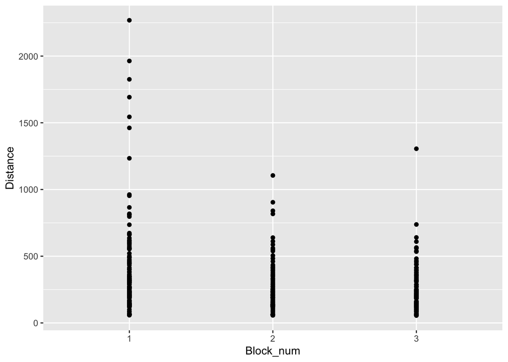

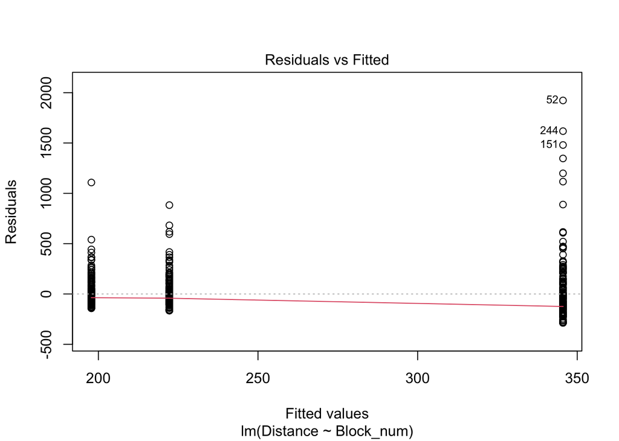

Below, we plot a Q-Q plot. The dots should lie along the line. Here, you see that this is not the case. This assumption fails.

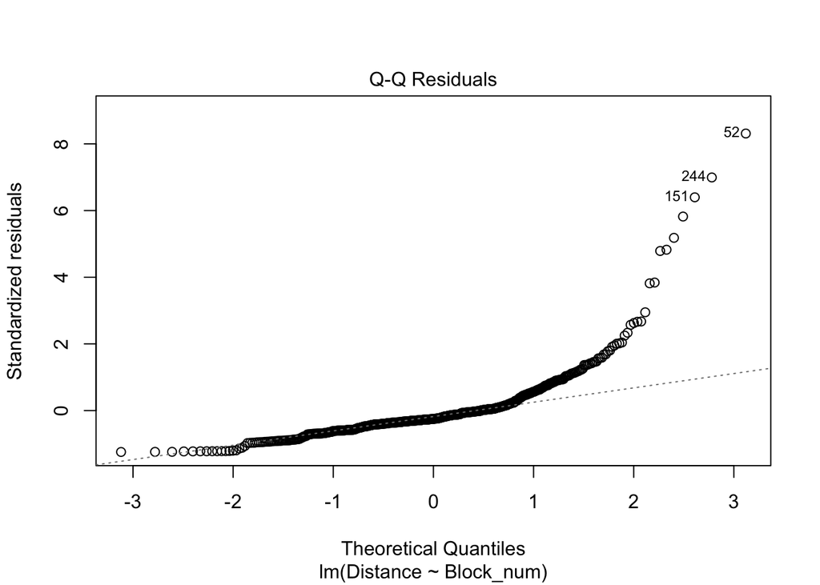

Since there’s not necessarily a directly linear relationship between our variables, and our explanatory variable is categorical, I’m not sure we can use a linear mixed model.

# Two-Way Nested ANOVA

Below is the two-way nested ANOVA.

```
##                                                  Df   Sum Sq Mean Sq F value
## nav_data$Block_num                                2  2307695 1153847  24.143
## nav_data$Block_num:factor(nav_data$Target_Name)  21  4309965  205236   4.294
## Residuals                                       528 25234617   47793
##                                                   Pr(>F)
## nav_data$Block_num                              9.27e-11 ***
## nav_data$Block_num:factor(nav_data$Target_Name) 1.29e-09 ***
## Residuals
## ---
## Signif. codes:  0 '***' 0.001 '**' 0.01 '*' 0.05 '.' 0.1 ' ' 1
```

Here’s a prelim plot that visually shows the comparisons we’re making above.

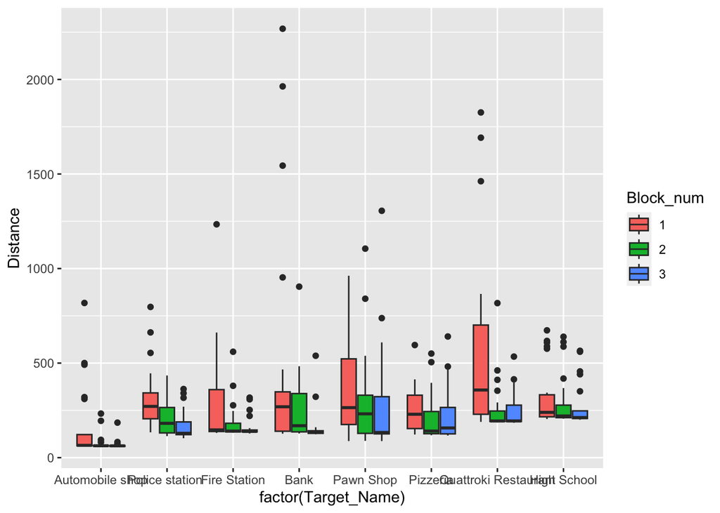